# Solutions to final exam (ds4psy)

Hansjörg Neth, SPDS, uni.kn

2018 07 16

# Introduction

The following questions comprise our **final exam** (on July 16, 2018).

This exam contains a total of **4 tasks** and a maximum score of **55 points** (plus 5 bonus points).

## Course coordinates

- Course [Data Science for Psychologists](http://rpository.com/ds4psy/) (ds4psy).
- Taught at the [University of Konstanz](https://www.uni-konstanz.de/) by [Hansjörg Neth](http://neth.de/) (h.neth@uni.kn, [SPDS](https://www.spds.uni-konstanz.de/), office D507).
- Spring/summer 2018: Mondays, 13:30–15:00, C511 (from 2018.04.16 to 2018.07.16)
- Links to [ZeUS](https://zeus.uni-konstanz.de:443/hioserver/pages/startFlow.xhtml?_flowId=showEvent-flow&unitId=5101&termYear=2018&termTypeValueId=1&navigationPosition=hisinoneLehrorganisation,examEventOverviewOwn) and [Ilias](https://ilias.uni-konstanz.de/ilias/goto_ilias_uni_crs_758039.html)

## Preparation and response format

**0.** Please answer the following questions by creating a single R script (or an R-Markdown file `.Rmd`) that contains all your code and answers and meets the following criteria:

- *Layout issues*:
  1. Include a header that contains your *name*, *student ID*, this *course*, and today’s *date*.
  2. Load the R packages of the `tidyverse`.
  3. Structure your file clearly by *labeling* the current task (e.g., `# Task 1: -----`) and subtask (e.g., `# (a) ...:`) and by *leaving blank lines* between all tasks and subtasks.

  Here’s a layout template that you can copy and adapt:

```r
## Final exam  | Data science for psychologists (Summer 2018)
## Name: ... | Student ID: ...
## 2018 07 16
## ~~~~~~~~~~~~~~~~~~~~~~~~~~~~~~~~~~~~~~~~~~~~~~~~~~~~~~~~~ ##

## Preparations: -----

library(tidyverse)

## Task 1: -----

# (a) Save data as tibble and inspect data:
pg <- as_tibble(PlantGrowth)
pg

## Answer: The PlantGrowth data contains 30 cases (rows) and 2 variables (columns).

## (b): ...
## ...

## ~~~~~~~~~~~~~~~~~~~~~~~~~~~~~~~~~~~~~~~~~~~~~~~~~~~~~~~~~ ##
## Task X: -----
## (a) ...

## ~~~~~~~~~~~~~~~~~~~~~~~~~~~~~~~~~~~~~~~~~~~~~~~~~~~~~~~~~ ##

## By submitting this script I assure that I have completed this
## script by myself (using only permissible sources of help).

## ~~~~~~~~~~~~~~~~~~~~~~~~~~~~~~~~~~~~~~~~~~~~~~~~~~~~~~~~~ ##
## End of file. -----
```

- Save your script (regularly) as `Lastname_Firstname_midTerm_180604.R` (replacing `Lastname` and `Firstname` by your names).
- When asked for numbers or interpretations, include *short answers as comments* in your script. However, when asked for quantitative summaries containing more than 2 numbers (e.g., descriptive statistics of a dataset) simply *print your results* (e.g., the output of a `dplyr` pipe) in your code.
- **Submit** your script as an attachment to an *email* (with the subject header “ds4psy: final exam”) to h.neth@uni.kn no later than on **Wednesday (July 18th, 2018)** and include a brief statement that assures that you have completed this work by yourself (using only permissible sources of help).

# Task 1: Plants

The `PlanthGrowth` data (contained in R datasets) reports the results from an experiment that compares growth yields (measured by the dried weight of plants) obtained under 2 treatments vs. a control condition.

**1a.** Save the `PlantGrowth` data as a tibble and inspect its dimensions. (1 point)

**1b.** Use a `dplyr` pipe to compute the number of observations (rows) in each `group` and some key descriptives (their mean, median, and standard deviation). (2 points)

**1c.** Use `ggplot` to create a graph that shows the medians and raw values of plant `weight` by `group`. (2 points)

**Hints:** Use 2 different geoms to show both medians and raw values in the same plot. The order of layers is determined by the order of geom commands.

```r
# ?datasets::PlantGrowth

# (a) Save as tibble and inspect data:
pg <- as_tibble(PlantGrowth)
pg # => 30 cases (rows) x 2 variables (columns)
```

```
#> # A tibble: 30 x 2
#>    weight group
#>     <dbl> <fct>
#>  1   4.17 ctrl
#>  2   5.58 ctrl
#>  3   5.18 ctrl
#>  4   6.11 ctrl
#>  5   4.50 ctrl
#>  6   4.61 ctrl
#>  7   5.17 ctrl
#>  8   4.53 ctrl
#>  9   5.33 ctrl
#> 10   5.14 ctrl
#> # ... with 20 more rows
```

```r
# (b) Compute number of observations by group, their mean, median and standard deviation:
pg %>%
  group_by(group) %>%
  summarise(count = n(),
            mn_weight = mean(weight),
            md_weight = median(weight),
            sd_weight = sd(weight)
            )
```

```
#> # A tibble: 3 x 5
#>   group count mn_weight md_weight sd_weight
#>   <fct> <int>     <dbl>     <dbl>     <dbl>
#> 1 ctrl     10      5.03      5.15     0.583
#> 2 trt1     10      4.66      4.55     0.794
#> 3 trt2     10      5.53      5.44     0.443
```

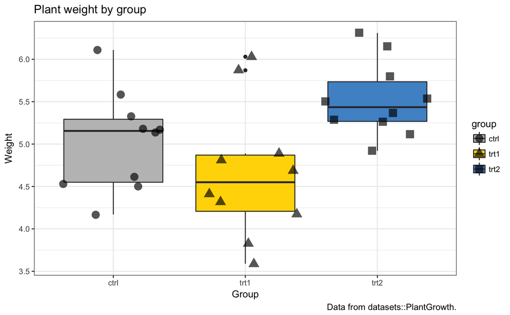

```r
# (c) Plot the median and raw values of weight by group:
ggplot(pg, aes(x = group, y = weight)) +
  # geom_violin() +
  geom_boxplot(aes(fill = group)) +
  geom_point(aes(shape = group), alpha = 2/3, size = 4, position = "jitter") +
  ## Pimping plot:
  labs(title = "Plant weight by group", x = "Group", y = "Weight",
       caption = "Data from datasets::PlantGrowth.") +
  scale_fill_manual(values = c("grey75", "gold", "steelblue3")) +
  theme_bw()

pt <- pt + 5  # increment point total
```

# Task 2: Hot and wet flights

Use the data set `nycflights13::weather` for questions that require `filter`, `arrange`, `select`, `group_by`, `summarise` (count, NAs, means, medians), etc.

**Hints:** As this task uses the `nycflights13::weather` dataset, make sure to have the package `nycflights13` installed to access this data.

```r
# install.packages(nycflights13) # install package
library(nycflights13) # load package
```

**2a.** Save the tibble `nycflights13::weather` as `wt` and report its dimensions. (1 point)

**2b.** Missing values and known unknowns:

- How many missing (`NA`) values does `sw` contain? (1 point)
- What is the percentage of missing (`NA`) values in `wt`? (1 point)
- What is the range (i.e., minimum and maximum value) of the `year` variable? (1 point)

**2c.** How many observations (rows) does the data contain for each of the 3 airports (`origin`)? (1 point)

**2d.** Compute a new variable `temp_dc` that provides the temperature (in degrees Celsius) that corresponds to `temp` (in degrees Fahrenheit).

**Hints:** The formula for conversion from Fahrenheit (degrees F) to Celsius (degrees C) is: $C = (F - 32) \times\ 5/9$.

Add your new `temp_dc` variable to a new dataset `wt_2` and re-arrange its columns so that your new `temp_dc` variable appears next to `temp`. (2 points)

**2e.** When only considering “JFK” airport:

- What are the 3 (different) dates with the (a) coldest and (b) hottest temperatures at this airport?

Report the 3 dates and their extreme temperatures (in degrees Celsius) for (a) and (b). (2 points)

**2f.** Plot the amount of mean precipitation by `month` for each of the 3 airports (`origin`). (2 points)

**Hint:** First use `dplyr` to compute a table of means (by `origin` and `month`). Then use `ggplot` to draw a line or bar plot of the means.

**2g.** For each of the 3 airports:

- When excluding extreme cases of precipitation (specifically, values of `precip` greater than 0.30):  
  Does it rain more during winter months (Oct to Mar) or during summer months (Apr to Sep)? (2 points)
- Plot the total amount of precipitation in winter vs. summer for each airport. (2 points)

**Hints:** Use `filter` to remove cases of extreme precipitation and create a logical variable (e.g., `summer`) that is `TRUE` for summer months and `FALSE` for winter months. The use `dplyr` to `summarise` the total amount (`sum`) of precipitation by `origin` and `summer`. The resulting tibble can be plotted as a bar chart (with different facets by `origin`).

```r
library(nycflights13)

# nycflights13::weather
# ?weather

## How many observations (rows) and variables (columns) does the data set contain overall?
wt <- nycflights13::weather
dim(wt)
```

```
#> [1] 26130    15
```

```r
## (b) missing values and ranges:
## - How many missing values does the `weather` data contain?
sum(is.na(wt))  # sum of NA values
```

```
#> [1] 3157
```

```r
mean(is.na(wt)) # percentage
```

```
#> [1] 0.008054599
```

```r
## - What is the range of values of the `year` variable?
range(wt$year)
```

```
#> [1] 2013 2013
```

```r
## (c) How many observations (rows) does the data contain for each of the 3 airports (`origin`)?
wt %>%
  group_by(origin) %>%
  count()
```

```
#> # A tibble: 3 x 2
#> # Groups: origin [3]
#>   origin     n
#>   <chr>  <int>
#> 1 EWR     8708
#> 2 JFK     8711
#> 3 LGA     8711
```

```r
## (d) Conversion from Fahrenheit to Celsius:
## Compute a variable `temp_dc` that provides the temperature (in degrees Celsius)
## that corresponds to `temp` (in degrees Fahrenheit).
## Fahrenheit (degrees F) to Celsius (degrees C) conversion:
## C = (F - 32) x 5/9.

## Add your new `temp_dc` variable to a new dataset `wt_2` and
## re-arrange its columns so that your `temp_dc` variable appears next to `temp`.

wt_2 <- wt %>%
  mutate(temp_dc = (temp - 32) * 5/9) %>%
  select(origin:temp, temp_dc, everything())
wt_2
```

```
#> # A tibble: 26,130 x 16
#>    origin  year month   day  hour  temp temp_dc  dewp humid wind_dir
#>    <chr>  <dbl> <dbl> <int> <int> <dbl>   <dbl> <dbl> <dbl>    <dbl>
#>  1 EWR     2013  1.00     1     0  37.0    2.80  21.9  54.0      230
#>  2 EWR     2013  1.00     1     1  37.0    2.80  21.9  54.0      230
#>  3 EWR     2013  1.00     1     2  37.9    3.30  21.9  52.1      230
#>  4 EWR     2013  1.00     1     3  37.9    3.30  23.0  54.5      230
#>  5 EWR     2013  1.00     1     4  37.9    3.30  24.1  57.0      240
#>  6 EWR     2013  1.00     1     6  39.0    3.90  26.1  59.4      270
#>  7 EWR     2013  1.00     1     7  39.0    3.90  27.0  61.6      250
#>  8 EWR     2013  1.00     1     8  39.0    3.90  28.0  64.4      240
#>  9 EWR     2013  1.00     1     9  39.9    4.40  28.0  62.2      250
#> 10 EWR     2013  1.00     1    10  39.0    3.90  28.0  64.4      260
#> # ... with 26,120 more rows, and 6 more variables: wind_speed <dbl>,
#> #   wind_gust <dbl>, precip <dbl>, pressure <dbl>, visib <dbl>, time_hour
#> #   <dttm>
```

```r
## (e) Only considering "JFK" airport:
## What are the 3 (different) dates with the (a) coldest and (b) hottest temperatures there?
## Report the 3 dates and their extreme temperatures (in degrees Celsius) for (a) and (b).
JFK_temp <- wt_2 %>%
  filter(origin == "JFK") %>%
  arrange(temp_dc)

JFK_temp # => coldest days
```

```
#> # A tibble: 8,711 x 16
#>    origin  year month   day  hour  temp temp_dc   dewp humid wind_dir
#>    <chr>  <dbl> <dbl> <int> <int> <dbl>   <dbl>  <dbl> <dbl>    <dbl>
#>  1 JFK     2013  1.00    23     9  12.0   -11.1 - 7.06  41.3    280
#>  2 JFK     2013  1.00    23    10  12.0   -11.1 - 5.08  45.4    280
#>  3 JFK     2013  1.00    23    11  12.0   -11.1 - 5.08  45.4    290
#>  4 JFK     2013  1.00    23     6  12.9   -10.6 - 9.04  36.0    290
#>  5 JFK     2013  1.00    23     7  12.9   -10.6 - 7.96  38.0    290
#>  6 JFK     2013  1.00    23     8  12.9   -10.6 - 7.06  39.7    290
#>  7 JFK     2013  1.00    23    12  12.9   -10.6 - 4.00  46.0    280
#>  8 JFK     2013  1.00    24     6  12.9   -10.6 - 2.02  50.5     40.0
#>  9 JFK     2013  5.00     9     2  13.1   -10.5  12.0   95.3     80.0
#> 10 JFK     2013  1.00    23     4  14.0   -10.0 - 9.94  32.9    300
#> # ... with 8,701 more rows, and 6 more variables: wind_speed <dbl>,
#> #   wind_gust <dbl>, precip <dbl>, pressure <dbl>, visib <dbl>, time_hour
#> #   <dttm>
```

```r
JFK_temp %>% arrange(desc(temp)) # => hottest days
```

```
#> # A tibble: 8,711 x 16
#>    origin  year month   day  hour  temp temp_dc  dewp humid wind_dir
#>    <chr>  <dbl> <dbl> <int> <int> <dbl>   <dbl> <dbl> <dbl>    <dbl>
#>  1 JFK     2013  7.00    18    16  98.1    36.7  66.9  36.4    260
#>  2 JFK     2013  7.00    18    15  97.0    36.1  68.0  39.0    330
#>  3 JFK     2013  7.00    18    18  97.0    36.1  71.1  43.4    220
#>  4 JFK     2013  7.00    16    18  96.1    35.6  62.1  32.6    360
#>  5 JFK     2013  7.00    18    14  96.1    35.6  66.9  38.7    350
#>  6 JFK     2013  7.00    18    17  96.1    35.6  71.1  44.6    250
#>  7 JFK     2013  7.00    15    20  95.0    35.0  68.0  41.5    360
#>  8 JFK     2013  7.00    16    17  95.0    35.0  60.1  31.4     20.0
#>  9 JFK     2013  7.00    17    15  95.0    35.0  64.9  37.3    350
#> 10 JFK     2013  7.00    20    20  95.0    35.0  69.1  43.1    260
#> # ... with 8,701 more rows, and 6 more variables: wind_speed <dbl>,
#> #   wind_gust <dbl>, precip <dbl>, pressure <dbl>, visib <dbl>, time_hour
#> #   <dttm>
```

```r
## Aggregation examples: -----

## (x) Average temperature per month:
##     (used in class):

mn_temp_month <- wt_2 %>%
  # group_by(origin, month) %>%
  group_by(month) %>%
  summarise(n = n(),
            n_not_NA = sum(!is.na(temp_dc)),
            mn_temp_dc = mean(temp_dc, na.rm = TRUE))
mn_temp_month
```

```
#> # A tibble: 12 x 4
#>    month     n n_not_NA mn_temp_dc
#>    <dbl> <int>    <int>      <dbl>
#>  1  1.00  2229     2229       2.02
#>  2  2.00  2010     2010       1.20
#>  3  3.00  2227     2227       4.34
#>  4  4.00  2159     2159      10.9
#>  5  5.00  2232     2232      16.4
#>  6  6.00  2160     2160      22.3
#>  7  7.00  2228     2228      26.7
#>  8  8.00  2217     2216      23.6
#>  9  9.00  2159     2159      19.7
#> 10 10.0   2212     2212      15.6
#> 11 11.0   2138     2138       7.28
#> 12 12.0   2159     2159       3.54
```

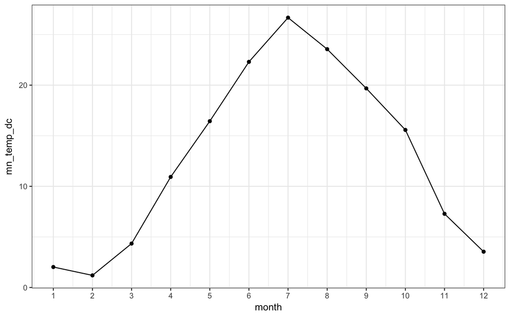

```r
ggplot(mn_temp_month, aes(x = month, y = mn_temp_dc)) +
  geom_point() +
  geom_line() +
  scale_x_continuous(breaks = 1:12) +
  theme_bw()
```

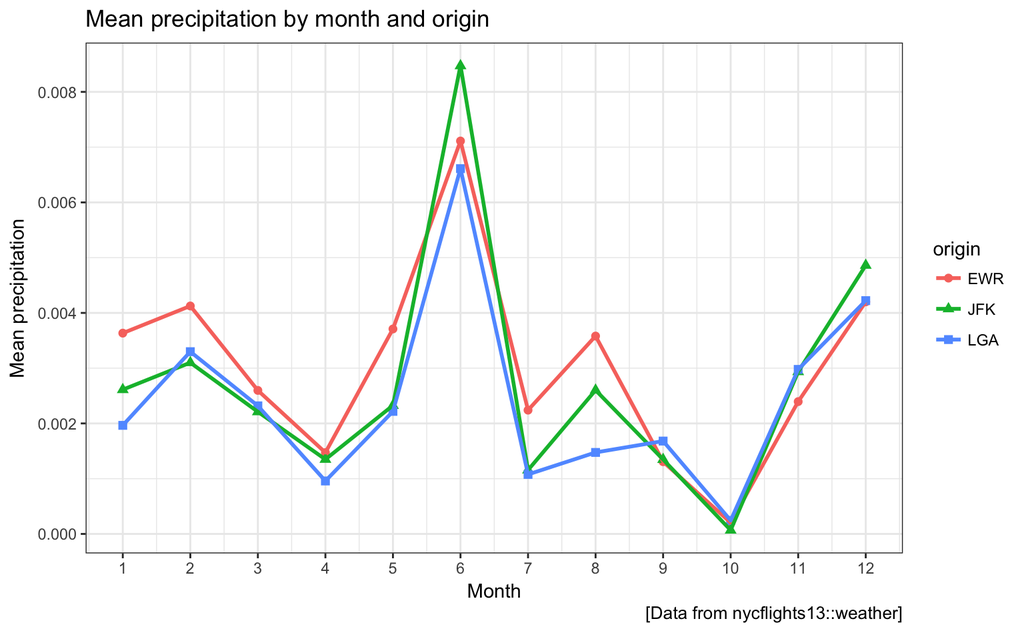

```r
## (f) Plot the amount of mean precipitation (by origin and month):

wt %>%
  group_by(origin, month) %>%
  summarise(n = n(),
            n_not_NA = sum(!is.na(precip)),
            mn_precip = mean(precip, na.rm = TRUE)) %>%
  ggplot(aes(x = month, y = mn_precip, color = origin, shape = origin)) +
  geom_point(size = 2) +
  geom_line(size = 1) +
  # geom_bar(aes(fill = origin), stat = "identity", position = "dodge") +
  scale_x_continuous(breaks = 1:12) +
  labs(title = "Mean precipitation by month and origin",
       x = "Month", y = "Mean precipitation",
       caption = "[Data from nycflights13::weather]") +
  theme_bw()
```

```r
## Computation and visualization to answer a question: ----

## (g) For each of the 3 airports:
## When excluding extreme cases of precipitation (values of `precip` greater than 0.30):
## Does it rain more during winter (Oct to Mar) or during summer (Apr to Sep) months?
## Plot the total amount of precipitation in winter vs. summer for each airport.

## Inspect data:
wt # month is given numerically!
```

```
#> # A tibble: 26,130 x 15
#>    origin  year month   day  hour  temp  dewp humid wind_dir wind_speed
#>    <chr>  <dbl> <dbl> <int> <int> <dbl> <dbl> <dbl>    <dbl>      <dbl>
#>  1 EWR     2013  1.00     1     0  37.0  21.9  54.0      230      10.4
#>  2 EWR     2013  1.00     1     1  37.0  21.9  54.0      230      13.8
#>  3 EWR     2013  1.00     1     2  37.9  21.9  52.1      230      12.7
#>  4 EWR     2013  1.00     1     3  37.9  23.0  54.5      230      13.8
#>  5 EWR     2013  1.00     1     4  37.9  24.1  57.0      240      15.0
#>  6 EWR     2013  1.00     1     6  39.0  26.1  59.4      270      10.4
#>  7 EWR     2013  1.00     1     7  39.0  27.0  61.6      250       8.06
#>  8 EWR     2013  1.00     1     8  39.0  28.0  64.4      240      11.5
#>  9 EWR     2013  1.00     1     9  39.9  28.0  62.2      250      12.7
#> 10 EWR     2013  1.00     1    10  39.0  28.0  64.4      260      12.7
#> # ... with 26,120 more rows, and 5 more variables: wind_gust <dbl>, precip
#> #   <dbl>, pressure <dbl>, visib <dbl>, time_hour <dttm>
```

```r
# ggplot(weather, aes(x = precip)) +
#  geom_histogram(binwidth = 0.01, fill = seeblau)

## Preparation: Filter out extreme values and add a summer variable:
weather_season <- wt %>%
  filter(precip <= .30) %>%
  mutate(summer = (month > 3 & month < 10)#,
         # winter = (month < 4 | month > 9)
         )

## Computation: Sum of precipitation by origin and summer season:
sum_rain_season <- weather_season %>%
  group_by(origin, summer) %>%
  summarise(n = n(),
            # n_not_NA = sum(!is.na(precip)),
            # mn_precip = mean(precip, na.rm = TRUE),
            sum_precip = sum(precip, na.rm = TRUE))
sum_rain_season
```

```
#> # A tibble: 6 x 4
#> # Groups: origin [?]
#>   origin summer     n sum_precip
#>   <chr>  <lgl>  <int>      <dbl>
#> 1 EWR    F       4320      10.9
#> 2 EWR    T       4380      11.9
#> 3 JFK    F       4323      10.3
#> 4 JFK    T       4379      10.3
#> 5 LGA    F       4323      10.0
#> 6 LGA    T       4384       9.21
```

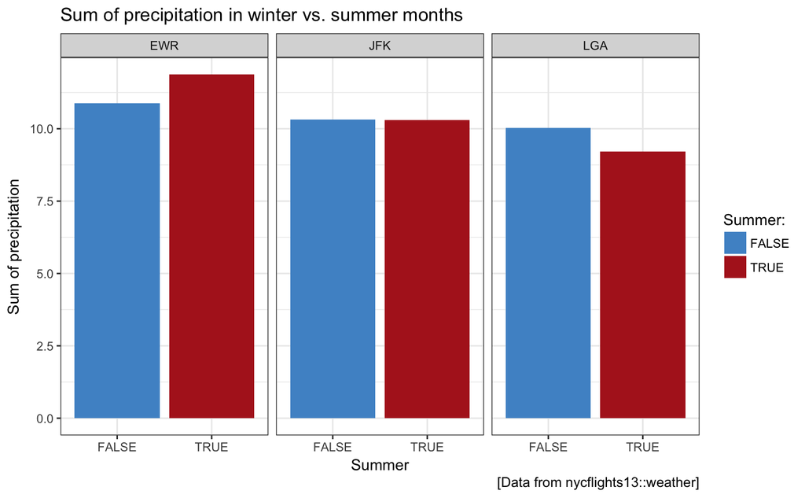

```r
## Visualization: Sum of precipitation as a bar chart:
ggplot(weather_season, aes(x = summer, fill = summer)) +
  facet_wrap(~origin) +
  geom_bar(aes(weight = precip), na.rm = TRUE) +
  scale_fill_manual(name = "Summer:", values = c("steelblue3", "firebrick")) +
  labs(title = "Sum of precipitation in winter vs. summer months",
       x = "Summer", y = "Sum of precipitation",
       caption = "[Data from nycflights13::weather]") +
  theme_bw()
```

```r
pt <- pt + 15  # increment point total
```

# Task 3: Numeracy vs. intelligence

This task uses a generated dataset (entitled `numeracy.csv` and available at http://rpository.com/ds4psy/data/numeracy.csv). Use the following `read_csv()` command to obtain and load it into R:

```r
## Load data (as comma-separated file):
data <- read_csv("http://rpository.com/ds4psy/data/numeracy.csv")  # from online source

## Alternatively (from local source):
# data <- read_csv("numeracy.csv")  # from current directory
```

### Understanding the data

The numeracy `data` is structured as follows:

- Each *row* contains the data from *one individual participant*.
- Six columns contain the following *independent variables* (IVs):
1. `name` contains each participant’s initials;
2. `gender`: each participant’s `gender`;
3. `bdate`: each participant’s birth date;
4. `bweekday`: the day of the week on which each participant was born;
5. `height`: how tall each participant is (in cm);
6. `blood_type`: each participant’s blood type;

The remaining six columns contain the following *dependent* variables (DVs):

- `bnt_1` to `bnt_4` signal a correct (1) or incorrect (0) answer to the corresponding question of the Berlin Numeracy Test (Cokely et al., 2012, see http://www.riskliteracy.org/researchers/ for details). The sum of these 4 variables define the BNT *numeracy* score for each participant.
- `g_iq` and `s_iq` provide two distinct measurements of each participant’s *general* vs. *social intelligence*.

### Your tasks

**(A) Basics:**

**3a.** Inspect the data dimensions and the percentage of missing values. (1 point)

**Hints:** As later parts of this task use variables created in earlier ones, you should either update your existing `data` with modified tibbles (e.g., including new variables) or incrementally save your new tibbles with new names (e.g., `data_a`, `data_b`, etc.).

**3b.** Split the birth date (`bdate`) variable into 3 separate variables (`byear`, `bmonth`, and `bday`) that denote the year, month, and day of each participant’s birth. (1 point)

**Hints:** Use `tidyr::separate` for this task, but check the type of your new variables (and use the `convert` argument to ensure that they are numeric).

**3c.** Create a new variable `summer_born` that is `TRUE` when a participant was born in summer (defined as April to September) and `FALSE` when a person was born in winter (October to March). (1 point)

**(B) Assessing IVs:**

**3d.** Compute the current `age` of each participant as the person would report it (i.e., in completed years, taking into account today’s date). (2 points)

**3e.** List the frequency of each blood type (`blood_type`) by *gender* (as a tibble by using `dplyr`) and re-format your tibble into a wider format (by using `tidyr`) that lists the types of `gender` in rows and the types of `blood_type` as columns. (2 points)

**3f.** Compute descriptives (the counts, means, and standard deviations) of `height` (a) by *gender* and (b) by *cohort* (i.e., the decade of birth). (3 points)

**Hints:** Use integer division on each participant’s `age` to determine his or her decade cohort: `cohort = age %/% 10`.

**3g.** Visualize the distributions of `height` (a) by *gender* and (b) by *cohort*. What do you find? (2 points)

**Hints:** Inspect the type of your `cohort` variable (by `typeof(my_data$cohort)`). Depending on your intended plot, you may have to turn this variable into a *factor* by using `as.factor(my_data$cohort)`. The factor has discrete levels, while the `cohort` variable may have been continuous (numeric).

**(C) Assessing DVs:**

**3h.** Compute the *aggregate* `BNT` *score* as the sum of all four `bnt_i` values (i.e., a value varying from 0 to 4) for each participant. How many *missing* `BNT` *values* are there? (1 point)

**3i.** Inspect the values for the 2 *intelligence* scores `g_iq` and `s_iq`:

- How many *missing values* are there?
- What are their *means* and their *ranges* (minimum and maximum values)?
- Plot their distributions in 2 separate *histograms*. (3 points)

**3j.** Visualize the relationship between `g_iq` and `s_iq`. Can you detect any systematic trend? (1 point)

**Hints:** Consider using a scatterplot, but take care of overplotting.

**(D) Exploring results:**

**3k.** Does *numeracy* (as measured by the aggregate `BNT` score) seem to vary by *gender*? (1 point)

**3l.** Assess possible effects of *numeracy* (as measured by `BNT`) on the 2 measures of intelligence (`g_iq` and `s_iq`). (2 points)

**3m.** Assess possible effects of the independent variables

- gender (`gender`),
- age (as provided by `age` or `cohort` from above),
- birth season (`summer_born`),
- blood type (`blood_type`), and
- the day of the week on which a person was born (`bweekday`),

on each of the 2 types of intelligence (`g_iq` and `s_iq`) in 2 ways:

1. *numercially* (by computing group means) and
2. *graphically* (by plotting means and/or distributions).

Which plausible or implausible effects does the data suggest? (10 points)

```r
## (A) Basics: -----

## (a) Inspect data:
data_a <- data
dim(data_a) # => 1000 participants x 12 variables
```

```
#> [1] 1000   12
```

```r
sum(is.na(data_a))   # 130 missing values
```

```
#> [1] 130
```

```r
mean(is.na(data_a))  # 1.083 percent of missing data
```

```
#> [1] 0.01083333
```

```r
# data_a

## (b) Split bdate into 3 separate variables (`byear`, `bmonth`, and `bday`):
# data_a$bdate       # inspect variable
length(data_a$bdate) # 1000 (i.e., no missing values)
```

```
#> [1] 1000
```

```r
data_b <- data_a %>%
  tidyr::separate(bdate, into = c("byear", "bmonth", "bday"), sep = "-",
                  convert = TRUE,
                  remove = FALSE) %>%
  select(name:bdate, byear, bmonth, bday, everything()) # re-arrange variables

# Note that byear:bmonth are converted into characters if convert = FALSE.
# Resulting data:
# data_b

## (c) Create a new variable `summer_born`:
##     `TRUE` iff born in summer (April to September)
data_c <- data_b %>%
  mutate(summer_born = (bmonth > 3) & (bmonth < 10)) %>%
  select(name:bday, summer_born, everything()) # re-arrange variables
# data_c

## (B) Assessing IVs: -----

## (d) Age in (completed) years:

# Today's date:
year_now  <- 2018
month_now <-    7
day_now   <-   13

data_d <- data_c %>%
  mutate(had_bday_this_year = (bmonth < month_now) | (bmonth = month_now & bday <= day_now),
         no_bday_this_year_yet = !had_bday_this_year,
         age = (year_now - byear) - no_bday_this_year_yet) %>%
  select(name:bday, age, everything()) # re-arrange variables
# data_d

# Note: A simpler solution using lubridate()
{
  library(lubridate)

  bday <- ymd("000713") # today, 18 years ago
  (bday %--% today())   # yields a time interval

  # Define a function that computes current age:
  cur_age <- function(bday) {

    lifetime <- (bday %--% today()) # interval from bday to today()
    (lifetime %/% years(1))         # integer division (into full years)

  }

  # Check:
  bday_1 <- ymd("000712") # year 2000 yesterday
  bday_2 <- ymd("000713") # year 2000 today
  bday_3 <- ymd("000714") # year 2000 tomorrow

  cur_age(bday_1) # => 18
  cur_age(bday_2) # => 18
  cur_age(bday_3) # => 17 (qed)
  }
```

```
#> [1] 17
```

```r
## (e) Frequency of blood_type

## by gender:
btg <- data_d %>%
  group_by(gender) %>%
  count(blood_type)
btg
```

```
#> # A tibble: 16 x 3
#> # Groups: gender [2]
#>    gender blood_type     n
#>    <chr>  <chr>      <int>
#>  1 female A+           194
#>  2 female A−            41
#>  3 female AB+            9
#>  4 female AB−            5
#>  5 female B+            37
#>  6 female B−             7
#>  7 female O+           204
#>  8 female O−            34
#>  9 male   A+           158
#> 10 male   A−            27
#> 11 male   AB+           15
#> 12 male   AB−            4
#> 13 male   B+            44
#> 14 male   B−             3
#> 15 male   O+           184
#> 16 male   O−            34
```

```r
## Re-format from long to wider format:
btg %>%
  spread(key = blood_type, value = n)
```

```
#> # A tibble: 2 x 9
#> # Groups: gender [2]
#>   gender  `A+`  `A−` `AB+` `AB−`  `B+`  `B−`  `O+`  `O−`
#> * <chr>  <int> <int> <int> <int> <int> <int> <int> <int>
#> 1 female   194    41     9     5    37     7   204    34
#> 2 male     158    27    15     4    44     3   184    34
```

```r
## (f+g) Descriptives and distribution of height by gender:
data_d %>%
  group_by(gender) %>%
  summarise(n = n(),
            n_notNA = sum(!is.na(height)),
            mn_height = mean(height, na.rm = TRUE),
            sd_height = sd(height, na.rm = TRUE)
            )
```

```
#> # A tibble: 2 x 5
#>   gender     n n_notNA mn_height sd_height
#>   <chr>  <int>   <int>     <dbl>     <dbl>
#> 1 female   531     531       161      8.79
#> 2 male     469     469       173     11.0
```

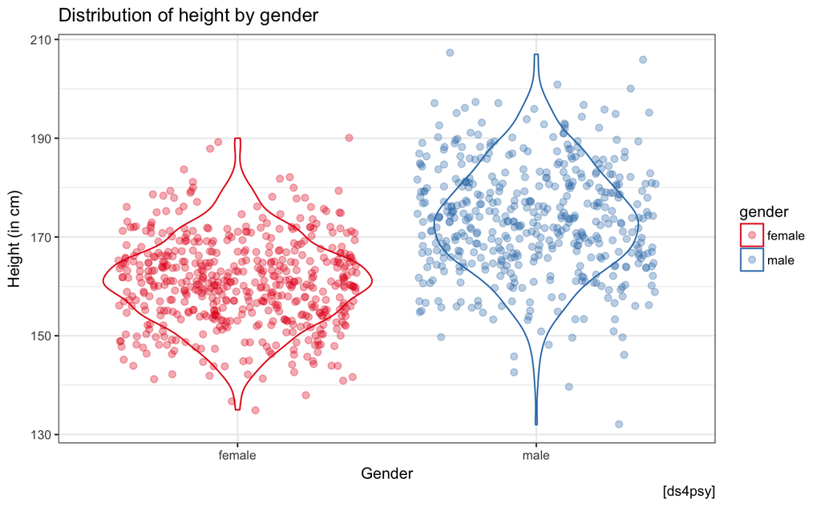

```r
ggplot(data_d, aes(x = gender, y = height, color = gender)) +
  geom_violin() +
  geom_jitter(size = 2, alpha = 1/3) +
  scale_color_brewer(palette = "Set1") +
  labs(title = "Distribution of height by gender",
       x = "Gender", y = "Height (in cm)",
       caption = "[ds4psy]") +
  theme_bw()
```

```r
## (f+g) Descriptives and distribution of height by cohort:
data_f <- data_d %>%
  mutate(cohort = age %/% 10)

data_f %>%
  group_by(cohort) %>%
  summarise(n = n(),
            n_notNA = sum(!is.na(height)),
            mn_height = mean(height, na.rm = TRUE),
            sd_height = sd(height, na.rm = TRUE)
            )
```

```
#> # A tibble: 9 x 5
#>   cohort     n n_notNA mn_height sd_height
#>    <dbl> <int>   <int>     <dbl>     <dbl>
#> 1   1.00    29      29       169     10.3
#> 2   2.00   157     157       171     12.1
#> 3   3.00   181     181       168     11.8
#> 4   4.00   162     162       167     10.7
#> 5   5.00   152     152       166     10.9
#> 6   6.00   127     127       167     11.4
#> 7   7.00   122     122       163     11.5
#> 8   8.00    60      60       160     12.6
#> 9   9.00    10      10       160      8.82
```

```r
# Inspect cohort:
typeof(data_f$cohort)
```

```
#> [1] "double"
```

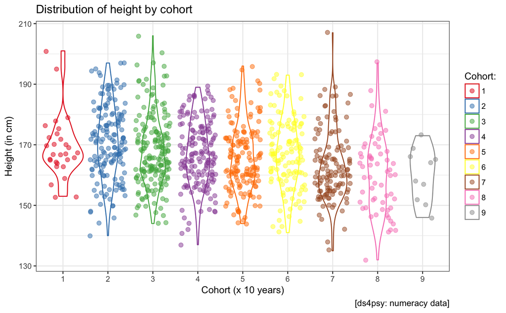

```r
data_f$cohort <- as.factor(data_f$cohort)

ggplot(data_f, aes(x = cohort, y = height, color = cohort)) +
  geom_violin() +
  geom_jitter(size = 2, alpha = 1/2) +
  scale_color_brewer(name = "Cohort:", palette = "Set1") +
  labs(title = "Distribution of height by cohort",
       x = "Cohort (x 10 years)", y = "Height (in cm)",
       caption = "[ds4psy: numeracy data]") +
  theme_bw()
```

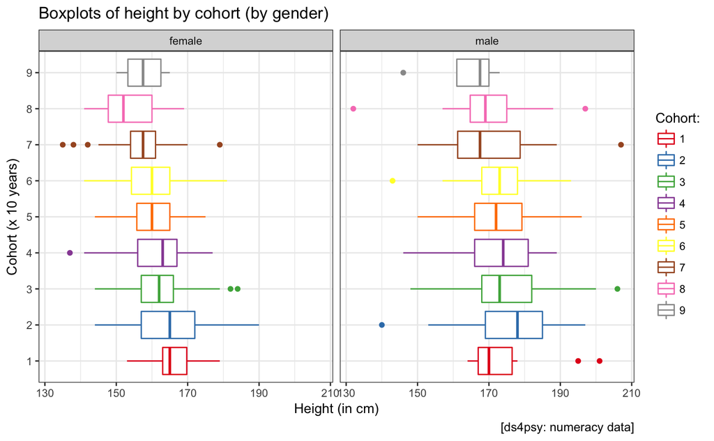

```r
# Visualizing distributions by both gender and cohort:
ggplot(data_f, aes(x = cohort, y = height, color = cohort)) +
  facet_wrap(~gender) +
  geom_boxplot() +
  scale_color_brewer(name = "Cohort:", palette = "Set1") +
  labs(title = "Boxplots of height by cohort (by gender)",
       x = "Cohort (x 10 years)", y = "Height (in cm)",
       caption = "[ds4psy: numeracy data]") +
  coord_flip() +
  theme_bw()
```

```r
## (C) Assessing DVs: -----
data_f
```

```
#> # A tibble: 1,000 x 20
#>    name  gender bdate      byear bmonth  bday   age summer_born bweekday
#>    <chr> <chr>  <date>     <int>  <int> <int> <dbl> <lgl>       <chr>
#>  1 I.G.  male   1968-12-14  1968     12    14  49.0 F           Sat
#>  2 O.B.  male   1974-04-10  1974      4    10  44.0 T           Wed
#>  3 M.M.  male   1987-09-28  1987      9    28  30.0 T           Mon
#>  4 V.J.  female 1978-02-15  1978      2    15  40.0 F           Wed
#>  5 O.E.  male   1985-05-18  1985      5    18  33.0 T           Sat
#>  6 Q.W.  male   1968-03-01  1968      3     1  50.0 F           Fri
#>  7 H.K.  male   1994-04-27  1994      4    27  24.0 T           Wed
#>  8 T.R.  female 1961-06-05  1961      6     5  57.0 T           Mon
#>  9 F.J.  male   1983-10-01  1983     10     1  35.0 F           Sat
#> 10 J.R.  female 1941-12-29  1941     12    29  76.0 F           Mon
#> # ... with 990 more rows, and 11 more variables: height <int>, blood_type
#> #   <chr>, bnt_1 <int>, bnt_2 <int>, bnt_3 <int>, bnt_4 <int>, g_iq <int>,
#> #   s_iq <int>, had_bday_this_year <lgl>, no_bday_this_year_yet <lgl>,
#> #   cohort <fct>
```

```r
# (h) BNT values:
data_h <- data_f %>%
  mutate(BNT = bnt_1 + bnt_2 + bnt_3 + bnt_4) %>%
  select(name:bnt_4, BNT, everything())

data_h %>%
  select(bnt_1:BNT)
```

```
#> # A tibble: 1,000 x 5
#>    bnt_1 bnt_2 bnt_3 bnt_4   BNT
#>    <int> <int> <int> <int> <int>
#>  1     1     0     0     1     2
#>  2     1     1     1    NA    NA
#>  3     0     1     0     0     1
#>  4     0     0     0     0     0
#>  5     1     0     0     0     1
#>  6     1     1     1     0     3
#>  7     0     1    NA     0    NA
#>  8     1     0     1     0     2
#>  9     0     0     0     0     0
#> 10     1     1     0     1     3
#> # ... with 990 more rows
```

```r
mean(is.na(data_h$BNT)) # 78 or 7.8% missing values.
```

```
#> [1] 0.078
```

```r
# (i) Inspecting g_iq and s_iq:
sum(is.na(data_h$g_iq)) # => 20 missing g_iq values
```

```
#> [1] 20
```

```r
sum(is.na(data_h$s_iq)) # => 30 missing g_iq values
```

```
#> [1] 30
```

```r
summary(data_h$g_iq, na.rm = TRUE) # mean of 101.9, range from 73 to 139.
```

```
#>    Min. 1st Qu.  Median    Mean 3rd Qu.    Max.    NA's
#>   73.00   95.75  101.00  101.91  108.00  139.00      20
```

```r
summary(data_h$s_iq, na.rm = TRUE) # mean of 102.0, range from 70 to 131.
```

```
#>    Min. 1st Qu.  Median    Mean 3rd Qu.    Max.    NA's
#>    70.0    95.0   102.0   102.0   109.8   131.0      30
```

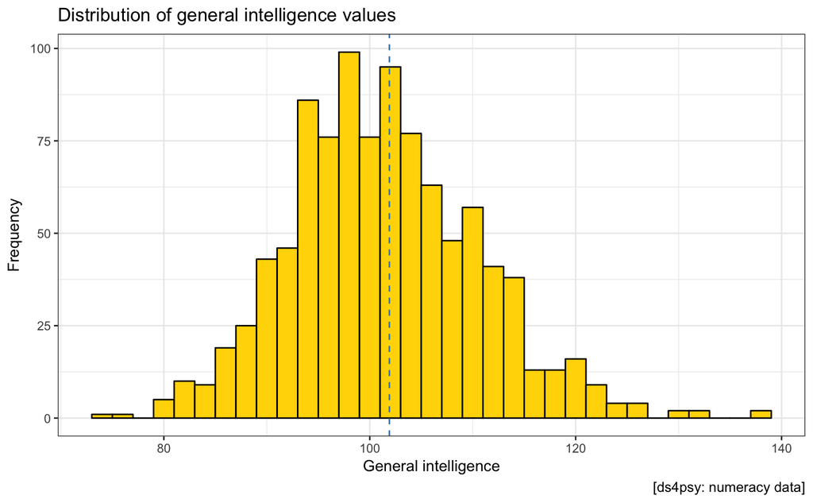

```r
# Save means and medians for plots:
mn_g_iq <- summary(data_h$g_iq, na.rm = TRUE)[["Mean"]]
md_g_iq <- summary(data_h$g_iq, na.rm = TRUE)[["Median"]]
mn_s_iq <- summary(data_h$s_iq, na.rm = TRUE)[["Mean"]]
md_s_iq <- summary(data_h$s_iq, na.rm = TRUE)[["Median"]]

ggplot(data_h) +
  geom_histogram(aes(x = g_iq), binwidth = 2, fill = "gold", color = "black") +
  geom_vline(xintercept = mn_g_iq, linetype = 2, color = "steelblue") +  # mark mean by vertical dashed line
  # geom_vline(xintercept = md_g_iq, linetype = 3, color = "steelblue") +  # mark median by vertical dotted line
  labs(title = "Distribution of general intelligence values",
       x = "General intelligence", y = "Frequency",
       caption = "[ds4psy: numeracy data]") +
  theme_bw()
```

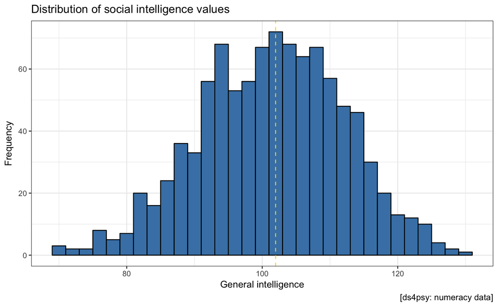

```r
ggplot(data_h) +
  geom_histogram(aes(x = s_iq), binwidth = 2, fill = "steelblue", color = "black") +
  geom_vline(xintercept = mn_s_iq, linetype = 2, color = "gold") +  # mark mean by vertical dashed line
  # geom_vline(xintercept = md_s_iq, linetype = 3, color = "gold") +  # mark median by vertical dotted line
  labs(title = "Distribution of social intelligence values",
       x = "General intelligence", y = "Frequency",
       caption = "[ds4psy: numeracy data]") +
  theme_bw()
```

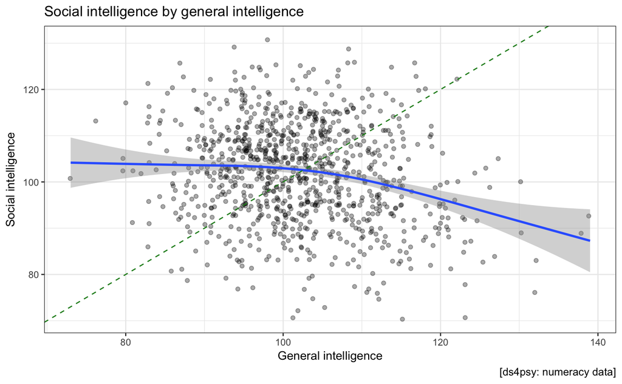

```r
# (j) Relationship between g_iq and s_iq:
ggplot(data_h, aes(x = g_iq, y = s_iq)) +
  geom_point(position = "jitter", alpha = 1/3) +
  geom_smooth() +
  geom_abline(color = "forestgreen", linetype = 2) +
  labs(title = "Social intelligence by general intelligence",
       x = "General intelligence", y = "Social intelligence",
       caption = "[ds4psy: numeracy data]") +
  # coord_fixed() +
  theme_bw()
```

```r
# => No clear relationship, but possibly a decline of s_iq with increasing g_iq.

## (D) Exploring results: -----

# +++ here now +++

pt <- pt + 30
```

# Task 4: Your data, your plot

Now it’s your turn to find and plot some data! Find a table with interesting data online (e.g., at [Wikipedia](https://en.wikipedia.org/)), load and save it (by copying or re-creating it) as a *tibble* in R, and then re-format, analyze, and visualize this tibble in one or several *graphs*. Your *goal* should be to illustrate some – but not necessarily all – key aspects of the data in a transparent fashion (i.e., making it easy to see some key observations, relationships between variables, or possible trends).

**Please note:** Your chosen data table should meet the following requirements:

1. Make sure to select a data source that has a *stable URL* that is cited in your script (to allow verifying the source and integrity of your data).
2. Your initial data table (tibble) should contain a *minimum* of 4 rows and 4 columns.

**Examples** of suitable sources include tables of

- [NBA scoring leaders](https://en.wikipedia.org/wiki/List_of_National_Basketball_Association_career_scoring_leaders),
- [refugee populations by country](https://en.wikipedia.org/wiki/List_of_countries_by_refugee_population#By_country_of_asylum), or
- the world’s [largest cities](https://en.wikipedia.org/wiki/List_of_largest_cities#Largest_cities).

**Hints:** If you choose some data of interest to you, this task should be fun, rather than a chore…

(5 points + up to 5 bonus points)

# Conclusion

## Counting tasks and points

This file contains **4 tasks** for a total of **55 points** (plus 5 possible bonus points).

## Cheers

I sincerely hope you enjoyed these tasks and this course.

All the best,  
Hansjörg Neth

[Last update on 2018-09-11 19:13:01 by [hn](http://neth.de/).]